# causal_alcohol_dysphagia

```r
library(IRdisplay)
display_html('<script>
code_show=true;
function code_toggle() {
  if (code_show){
    $(\'div.input\').hide();
  } else {
    $(\'div.input\').show();
  }
  code_show = !code_show
}
$( document ).ready(code_toggle);
</script>
  <form action="javascript:code_toggle()">
    <input type="submit" value="Click here to toggle on/off the raw code.">
 </form>'
)
```

Date: July 28, 2017

Author: Wei

```r
library(boot)
library(randomForest)
library(foreach)
library(doParallel)

rm(list=ls())
```

```r
# Input:
# df: a data frame to be resampled
# k: number of resampled datasets to generate.
# f: a function of df giving the bootstrap statistic
# (e.g. function(df) { mean(df$x1) })
# q: a real number 0 < q
# Output: a three element vector giving the statistic of interest (first element),
# and lower and upper confidence intervals corresponding to
# q and 1-q quantiles (second and third elements) of the empirical
# bootstrap distribution.

bootstrap_ci <- function(df, k, f, q){
    df_resample <- function(df){
  ind <- sample(1:nrow(df),size = nrow(df), replace = TRUE)
  return(df[ind,])
    }
  cl <- makeCluster(7)
  registerDoParallel(cl)
#   means <- vector(mode = "numeric", length = k)
  original_mean <- f(df)

  means <- foreach (i=1:k, .packages="randomForest") %dopar% {
    data <- df_resample(df)
    f(data)
  }
  stopCluster(cl)

  means <- unlist(means)
  diff_statistics <- quantile(means-original_mean, probs = c(q,1-q))
  diff_statistics <- unname(diff_statistics)

  return(c(original_mean, original_mean + diff_statistics[1], original_mean + diff_statistics[2] ))
}
```

### Get dataset

```r
df<- read.csv("post.csv", TRUE, ",")
df$mdadi_total <-NULL
head(df, n=2L)
```

| X | tstage | nstage | mstage | weight | pain | dysphagia | dysgeusia | kps | smoking | ... | hpv_ever_positive | comb_chemo | peg_ever_used | ng_ever_used | tube_ever_used | ssq_total | height | sex | race | diag_site |
| --- | --- | --- | --- | --- | --- | --- | --- | --- | --- | --- | --- | --- | --- | --- | --- | --- | --- | --- | --- | --- |
| 1 | 3 | 2 | 0 | 91.7 | 2 | 3 | 2 | 100 | 2 | ... | 1 | 1 | 1 | 0 | 1 | 450.4 | 180 | Male | Caucasian | other |
| 2 | 1 | 2 | 0 | 208.2 | 7 | 2 | 2 | 100 | 2 | ... | 1 | 1 | 0 | 0 | 0 | 146.4 | 176 | Male | Caucasian | oral cavity |

Number of patients:

```r
nrow(df)
```

217

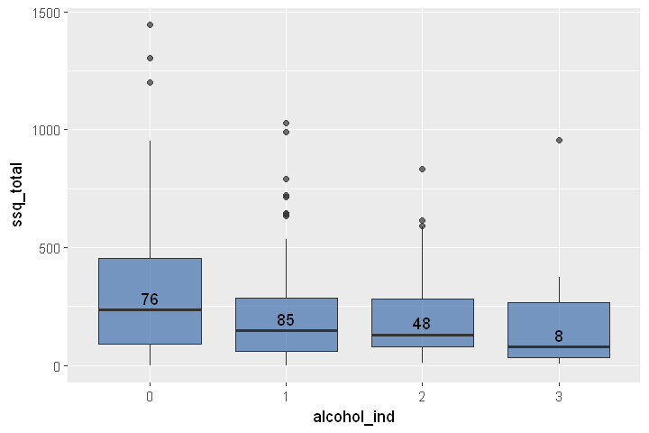

```r
library(repr)
library(ggplot2)
options(repr.plot.width=6, repr.plot.height=4)

df$alcohol_ind <- as.factor(df$alcohol_ind)
# function for number of observations
give.n <- function(x){
  return(c(y = median(x)+50, label = length(x)))
}
p10 <- ggplot(df, aes(x = alcohol_ind, y = ssq_total)) +
        geom_boxplot(fill = "#4271AE", alpha = 0.7)+
        stat_summary(fun.data = give.n, geom = "text", fun.y = median)
p10

# p10<-ggplot(df, aes( x = ssq_total))+geom_hist()
```

### Method 1: Adjust for all other baseline covariates. (Parametric g-formula)

Average causal effect: $$ \frac{1}{n}\sum_i (E[Y \ |\ A=1, x_i; \hat{\alpha}] -E[Y \ | \ A=0,x_i;\hat{\alpha}])$$

$Y$: outcome, dysphagia measured as ssq score, in our case  
$A$: treatment, alcohol, in our case  
$x_i$: all the other covariates or potential confounders  
$\hat{\alpha}$: parameter for model $E[Y \ | \ A, X]$

```r
## Compute average causal effect
ACE_g <- function(post){
    bag.post = randomForest(ssq_total~., data = post, ntree = 500)

    post0 <- post
    post2 <- post
    post0$alcohol_ind <-0
    post2$alcohol_ind <-1

    yhat.bag0 = predict(bag.post, newdata= post0)

    yhat.bag2 = predict(bag.post, newdata= post2)

    delta <- mean(yhat.bag2 - yhat.bag0)
    return(delta)
}

main1 = function(){

  df<- read.csv("post.csv", TRUE, ",")
  df$mdadi_total <- NULL
  set.seed(1)
  k <- 500
  ci <- bootstrap_ci(df, k, ACE_g, q = 0.025)
  print("Average causal effect of alcohol (0 vs 1) on ssq score:")
  print(ci[1])
  print("Confidence interval (95%):")
  print(ci[2:3])

}

main1()
```

```
[1] "Average causal effect of alcohol (0 vs 1) on ssq score:"
[1] -26.83457
[1] "Confidence interval (95%):"
[1] -54.824986  -3.660523
```

### Method 2: inverse probability weighting

1. Estimate propensity score $\textbf{P}(\textbf{alcohol} \ | \ \textbf{all other covariates})$ using multi-class random forest

Average causal effect (from Ilya): $$\frac{1}{N_1}\sum_i^n\frac{I(A_i =a_1)}{P(A_i=a_1 \ |\ x_i)}y_i - \frac{1}{N_0}\sum_i^n\frac{I(A_i =a_0)}{P(A_i=a_0 \ |\ x_i)}y_i $$

where:

$A$: treatment, in our case, alcohol use

$y$: dysphagia, ssq score

$x$: all the other covariates, or potential confounders

$$N_1 = \sum_i^n\frac{I(A_i =a_1)}{P(A_i=a_1 \ |\ x_i)}$$$$N_0 = \sum_i^n\frac{I(A_i =a_0)}{P(A_i=a_0 \ |\ x_i)}$$

```r
ACE_IPW <- function(df, verbose=FALSE){
    df$alcohol_ind <- as.factor(df$alcohol_ind)

    data_train <- df[,names(df) != "ssq_total"]
    m <- randomForest(alcohol_ind~., data = data_train, ntree=500)

#     m <- polr(alcohol_ind~., data=data_train, Hess=TRUE)
#     summary(m)
#     ctable <- coef(summary(m))
#     p <- pnorm(abs(ctable[, "t value"]), lower.tail = FALSE) * 2
#     ctable <- cbind(ctable, "p value" = p)
    # confidence intervals
#     ci <- confint(m)
    probs <- predict(m, data_train, type="p")
    if (verbose){
        print(probs)
    }
    weight <- 1/probs
    weight0 <- weight[df$alcohol_ind==0, c("0")]
    weight2 <- weight[df$alcohol_ind==1, c("1")]

    y0 <- df[df$alcohol_ind=="0",c("ssq_total")]
    y2 <- df[df$alcohol_ind=="1",c("ssq_total")]

    return(sum(y2*weight2)/sum(weight2) - sum(y0*weight0)/sum(weight0))
}
```

```r
main2 = function(){

  df<- read.csv("post.csv", TRUE, ",")
  df$mdadi_total <- NULL

  set.seed(1)
  k <- 500
  ci <- bootstrap_ci(df, k, ACE_IPW, q = 0.025)
  print("Average causal effect of alcohol (0 vs 1) on ssq score:")
  print(ci[1])
  print("Confidence interval (95%):")
  print(ci[2:3])

}

main2()
```

```
[1] "Average causal effect of alcohol (0 vs 1) on ssq score:"
[1] -115.0497
[1] "Confidence interval (95%):"
[1] -200.95228  -39.05029
```

## Meeting at July 28,2017

### Ilya: Look at augmented-IPW

### look at cumulative alcohol effect, alcohol trajectory

### Method 3: augmented inverse probability weighting

1. Estimate propensity score $\textbf{P}(\textbf{alcohol} \ | \ \textbf{all other covariates})$ using multi-class random forest
2. Fit a random forest regression estimator to predict $E[Y \ |\ A_i, x_i; \hat{\alpha}]$
3. Estimate average causal effect using following augmented inverse probability weighting estimator:

$$ACE = \frac{1}{n}\sum_i^n\{\frac{I(A_i =a_1)}{P(A_i=a_1 \ |\ x_i)}y_i - \frac{I(A_i =a_1)-P(A_i=a_1 \ |\ x_i)}{P(A_i=a_1 \ |\ x_i)}E[Y \ |\ A=a_1, x_i; \hat{\alpha}] - \frac{I(A_i =a_0)}{P(A_i=a_0 \ |\ x_i)}y_i + \frac{I(A_i =a_0)-P(A_i=a_0 \ |\ x_i)}{P(A_i=a_0 \ |\ x_i)}E[Y \ |\ A=a_0, x_i; \hat{\alpha}] \}$$

We can prove that this ACE estimator is consistent if either the propensity score model in step 1 or the regression model in step 2 is correctedly specified.

```r
ACE_AIPW <- function(df, verbose=FALSE){
    # Estimate propensity score
    df_copy <- df
    df$alcohol_ind <- as.factor(df$alcohol_ind)

    data_train <- df[,names(df) != "ssq_total"]
    m <- randomForest(alcohol_ind~., data = data_train, ntree=500)

    probs <- predict(m, data_train, type="p")
    if (verbose){
        print(probs)
    }
    weight <- 1/probs
    weight0 <- weight[df$alcohol_ind==0, c("0")]
    weight2 <- weight[df$alcohol_ind==1, c("1")]

    y0 <- df[df$alcohol_ind=="0",c("ssq_total")]
    y2 <- df[df$alcohol_ind=="1",c("ssq_total")]

    # Fit regression model
    bag.post = randomForest(ssq_total~., data = df_copy, ntree = 500)

    post0 <- df_copy
    post2 <- df_copy
    post0$alcohol_ind <-0
    post2$alcohol_ind <-1

    yhat.bag0 = predict(bag.post, newdata= post0)
    yhat.bag2 = predict(bag.post, newdata= post2)


    yhat_00 = yhat.bag0[df_copy$alcohol_ind==0]
    yhat_01 = yhat.bag0[df_copy$alcohol_ind==1]

    yhat_10 = yhat.bag2[df_copy$alcohol_ind==0]
    yhat_11 = yhat.bag2[df_copy$alcohol_ind==1]

    ace_score = 1/nrow(df) * (sum(y2*weight2) - sum((weight2 - 1)*yhat_11) + sum(yhat_10) -
    (sum(y0*weight0) - sum((weight0 - 1)*yhat_00) + sum(yhat_01)))

    return(ace_score)
}
```

```r
main3 = function(){

  df<- read.csv("post.csv", TRUE, ",")
  df$mdadi_total <- NULL

  set.seed(1)
  k <- 500
  ci <- bootstrap_ci(df, k, ACE_AIPW, q = 0.025)
  print("Average causal effect of alcohol (0 vs 1) on ssq score:")
  print(ci[1])
  print("Confidence interval (95%):")
  print(ci[2:3])
}

main3()
```

```
[1] "Average causal effect of alcohol (0 vs 1) on ssq score:"
[1] -31.8824
[1] "Confidence interval (95%):"
[1] -50.776989  -4.100679
```